# Korpus native tekstova

Lux

2023-03-25

# Basic descriptives

#### Vremenski raspon analize

#### Deskriptiva na dnevnoj razini

#### Broj objava po danima

#### Broj objava po izvoru

|  | FROM | count | percent |
| --- | --- | --- | --- |
| 1 | jutarnji.hr | 177 | 32.6 |
| 2 | vecernji.hr | 103 | 18.97 |
| 3 | telegram.hr | 99 | 18.23 |
| 4 | 24sata.hr | 88 | 16.21 |
| 5 | index.hr | 62 | 11.42 |
| 6 | slobodnadalmacija.hr | 14 | 2.58 |

Objava po izvorima

| Izvor | Broj objava | % |
| --- | --- | --- |
| jutarnji.hr | 177 | 32.60 |
| vecernji.hr | 103 | 18.97 |
| telegram.hr | 99 | 18.23 |
| 24sata.hr | 88 | 16.21 |
| index.hr | 62 | 11.42 |
| slobodnadalmacija.hr | 14 | 2.58 |

# Text analysis

#### Najčešće riječi (>50)

#### Najčešće riječi 24h.hr

#### Najčešće riječi jutarnji.hr

#### Najčešće riječi telegram.hr

#### Najčešće riječi vecernji.hr

#### Najčešće riječi index.hr

#### Doprinos riječi sentimentu (za sve native članke koje ste pronašli)

# CroSentilex sentiment (positive, negative, neutral)

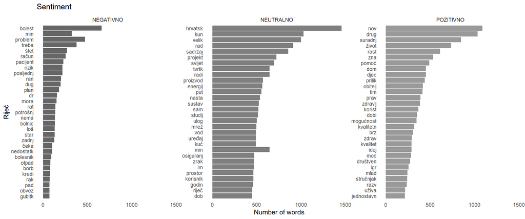

# NRC sentiment (positive vs. negative)

# NRC sentiment (“Anger”,“Anticipation”,“Disgust”,“Fear”,“Joy”,“Sadness”,“Surprise”,“Trust”)

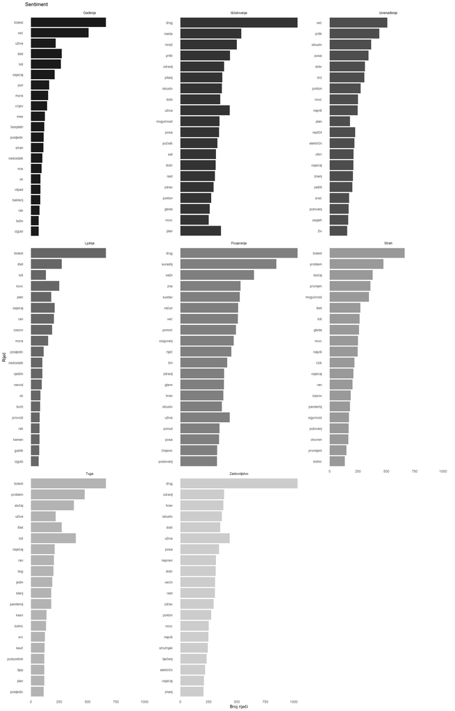

#### Oblak riječi sa sentimentom CroSentilex (za sve native članke koje ste pronašli)

#### Oblak riječi sa sentimentom NRC (za sve native članke koje ste pronašli) **da li treba dodati za portale?**

#### Oblak riječi sa sentimentom (za sve native članke koje ste pronašli za 24sata.hr)

#### Oblak riječi sa sentimentom (za sve native članke koje ste pronašli za večernji.hr)

#### Oblak riječi sa sentimentom (za sve native članke koje ste pronašli za jutranji.hr)

#### Oblak riječi sa sentimentom (za sve native članke koje ste pronašli za index.hr)

#### Oblak riječi sa sentimentom (za sve native članke koje ste pronašli za sdalmancija.hr)

#### Oblak riječi sa sentimentom (za sve native članke koje ste pronašli za telegram.hr)

#### Najbitnije riječi po portalima prema tf-idf metodi(ovo bi bilo dobro pogledati prema drugim kriterijima osim portala)

#### Najčešće freze (bigrami; moguće i za 3 ili više riječi)

#### Riječi najkoreliranjije sa izabranim riječima (bolest, rizik, strah; moguće dodati druge koje sugerirate)

#### Riječi najkoreliranjije sa izabranim riječima (problem, račun)

#### Tematska analiza (riječi algoritamski svrstane u 3 teme;moguće napraviti i po portalima)

## Pregled varijabli prema Davor&Drazen

### Industrija

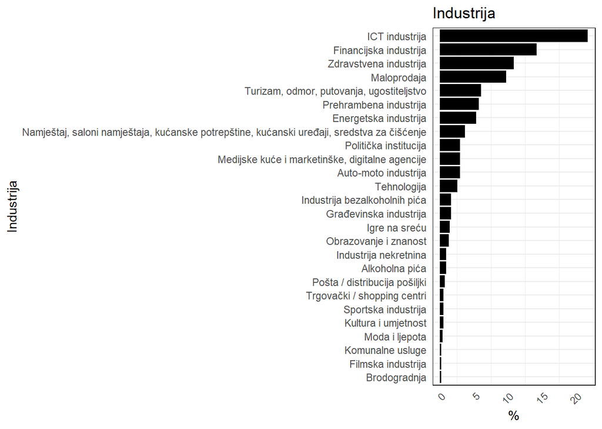

Pregled po industrijama

| Industrija | Broj objava | % |
| --- | --- | --- |
| ICT industrija | 118 | 21.73 |
| Financijska industrija | 77 | 14.18 |
| Zdravstvena industrija | 59 | 10.87 |
| Maloprodaja | 53 | 9.76 |
| Turizam, odmor, putovanja, ugostiteljstvo | 33 | 6.08 |
| Prehrambena industrija | 31 | 5.71 |
| Energetska industrija | 29 | 5.34 |
| Namještaj, saloni namještaja, kućanske potrepštine, kućanski uređaji, sredstva za čišćenje | 20 | 3.68 |
| Politička institucija | 16 | 2.95 |
| Auto-moto industrija | 16 | 2.95 |
| Medijske kuće i marketinške, digitalne agencije | 16 | 2.95 |
| Tehnologija | 14 | 2.58 |
| Građevinska industrija | 9 | 1.66 |
| Industrija bezalkoholnih pića | 9 | 1.66 |
| Igre na sreću | 8 | 1.47 |
| Obrazovanje i znanost | 7 | 1.29 |
| Alkoholna pića | 5 | 0.92 |
| Industrija nekretnina | 5 | 0.92 |
| Pošta / distribucija pošiljki | 4 | 0.74 |
| Sportska industrija | 3 | 0.55 |
| Kultura i umjetnost | 3 | 0.55 |
| Trgovački / shopping centri | 3 | 0.55 |
| Moda i ljepota | 2 | 0.37 |
| Filmska industrija | 1 | 0.18 |
| Brodogradnja | 1 | 0.18 |
| Komunalne usluge | 1 | 0.18 |

### Porijeklo

|  | HRV.IL.STRANI.BREND | N | percentPORIJEKLO |
| --- | --- | --- | --- |
| 1 | 1 | 259 | 47.7 |
| 2 | 2 | 284 | 52.3 |

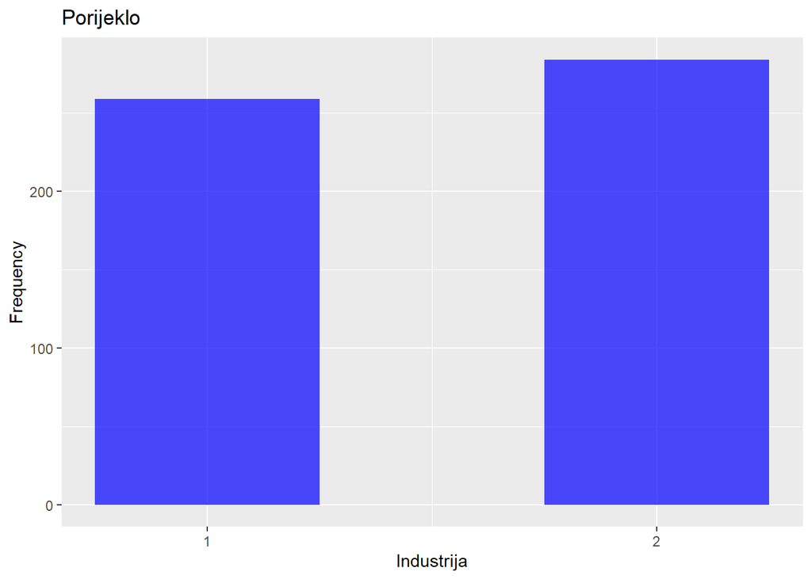

### Brend

### Premium

### Autorstvo

Autorstvo

| Autorstvo | Broj objava | % |
| --- | --- | --- |
| Nativni tim / studio | 240 | 44.20 |
| Sponzorirani sadržaj / PR sadržaj | 117 | 21.55 |
| Ime i prezime autora / sponzorirani sadržaj | 86 | 15.84 |
| Autor / puno ime i prezime | 48 | 8.84 |
| Nije naveden autor | 48 | 8.84 |
| Organizacija / udruga / tvrtka / zajednica | 3 | 0.55 |
| Redakcija / redakcijski izvještaj | 1 | 0.18 |

### Rubrika

Rubrika

| Rubrika | Broj objava | % |
| --- | --- | --- |
| Native | 117 | 21.55 |
| Promo | 88 | 16.21 |
| Partneri | 72 | 13.26 |
| Magazin / mozaik / zabava | 60 | 11.05 |
| Lifestyle / estrada / celebrity / scena / showbiz | 39 | 7.18 |
| Dom i dizajn | 32 | 5.89 |
| Financije / novac / biznis / poduzetnički savjetnik | 29 | 5.34 |
| Vijesti | 28 | 5.16 |
| Zdravlje, zdrav život | 15 | 2.76 |
| Openspace (Telegram.hr) | 14 | 2.58 |
| Auto-moto | 13 | 2.39 |
| Tehnologija / znanost (tech-sci) | 12 | 2.21 |
| Sport | 9 | 1.66 |
| Prehrana / gastro / dobra hrana | 9 | 1.66 |
| Lokalna rubrika | 6 | 1.10 |

### Clickbait

### Brend u naslovu

### Vrsta rečenice naslovu

### Oprema

### Vizualni identitet

### Poveznice

Pregled poveznica

| Poveznica | Broj objava | % |
| --- | --- | --- |
| Službena internetska stranica brenda | 373 | 68.69 |
| Članak ne sadrži poveznice na kanale brenda / oglašivača | 74 | 13.63 |
| Više kombinacija | 60 | 11.05 |
| Poveznica nevezana za brend | 20 | 3.68 |
| Suradnja oglašivača i drugog brenda | 13 | 2.39 |
| Društvene mreže brenda | 2 | 0.37 |

### Izvori

### Formulacija uz izvor

#### Doseg

Doseg publike

| Razredi dosega | Broj objava | % |
| --- | --- | --- |
| 10 000 - 20 000 | 222 | 40.88 |
| 5 000 - 10 000 | 186 | 34.25 |
| 2 000 - 5 000 | 76 | 14.00 |
| 20 000 - 50 000 | 30 | 5.52 |
| 0 - 2 000 | 27 | 4.97 |
| 50 000 - 100 000 | 1 | 0.18 |
| 100 000 - 200 000 | 1 | 0.18 |

#### Lajkovi

#### Komentari

#### Interakcije

## Dodatno (nakon zadnjeg sastanka)

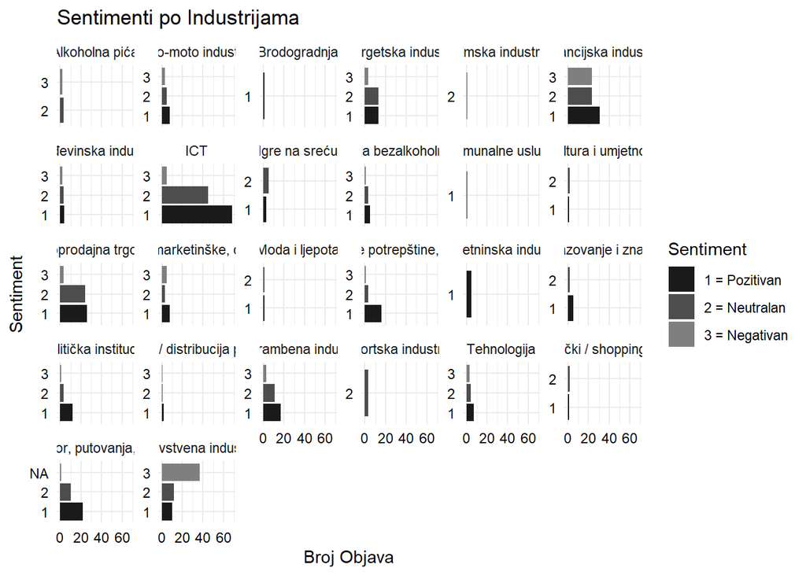

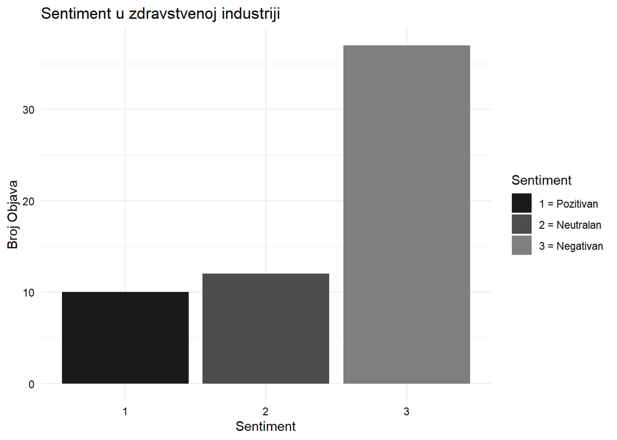

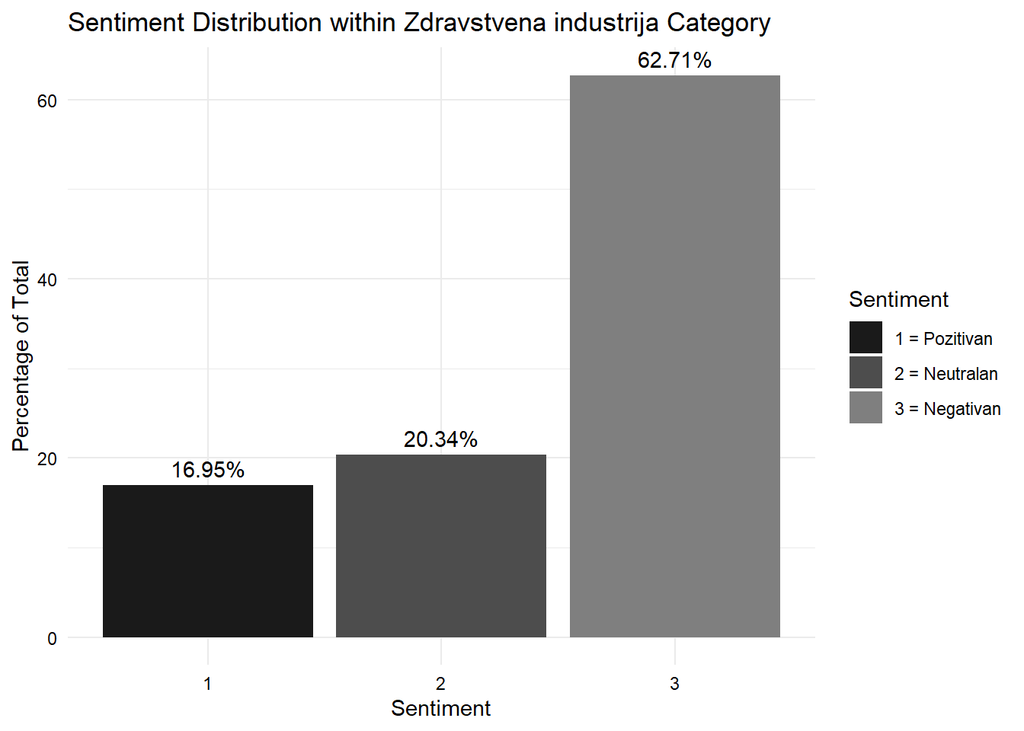

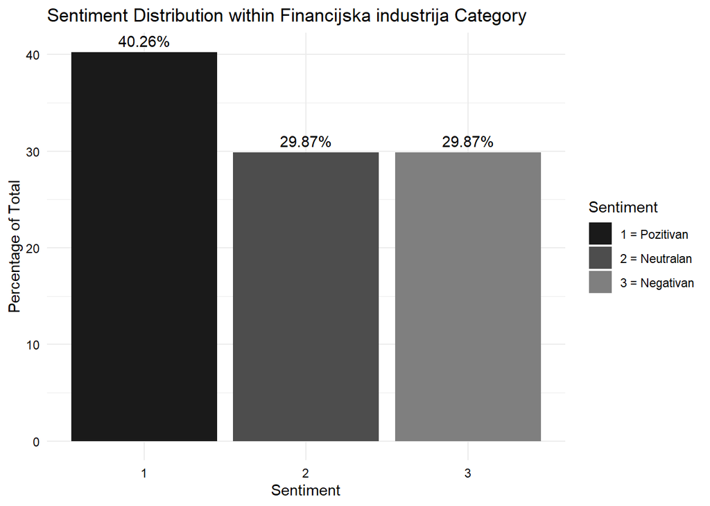

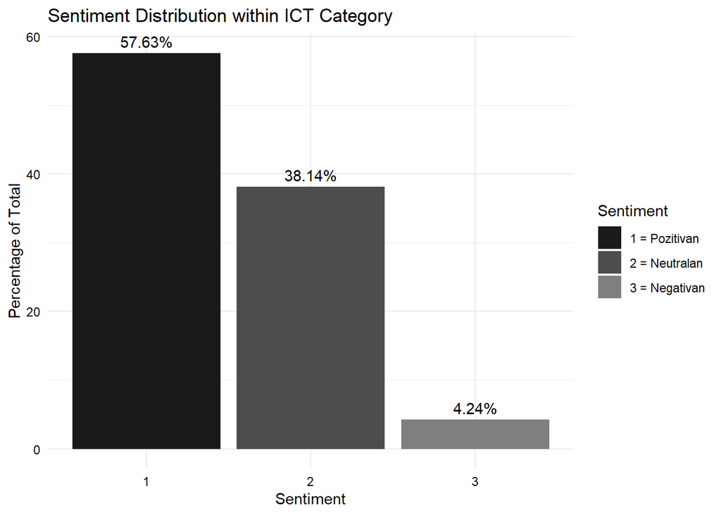

#### Sentiment: 6. Sentiment – pozitivan, negativan ili neutralan

Pregled sentimenta

| Sentiment | Broj objava | % |
| --- | --- | --- |
| Pozitivan | 267 | 49.17 |
| Neutralan | 182 | 33.52 |
| Negativan | 93 | 17.13 |
| NA | 1 | 0.18 |

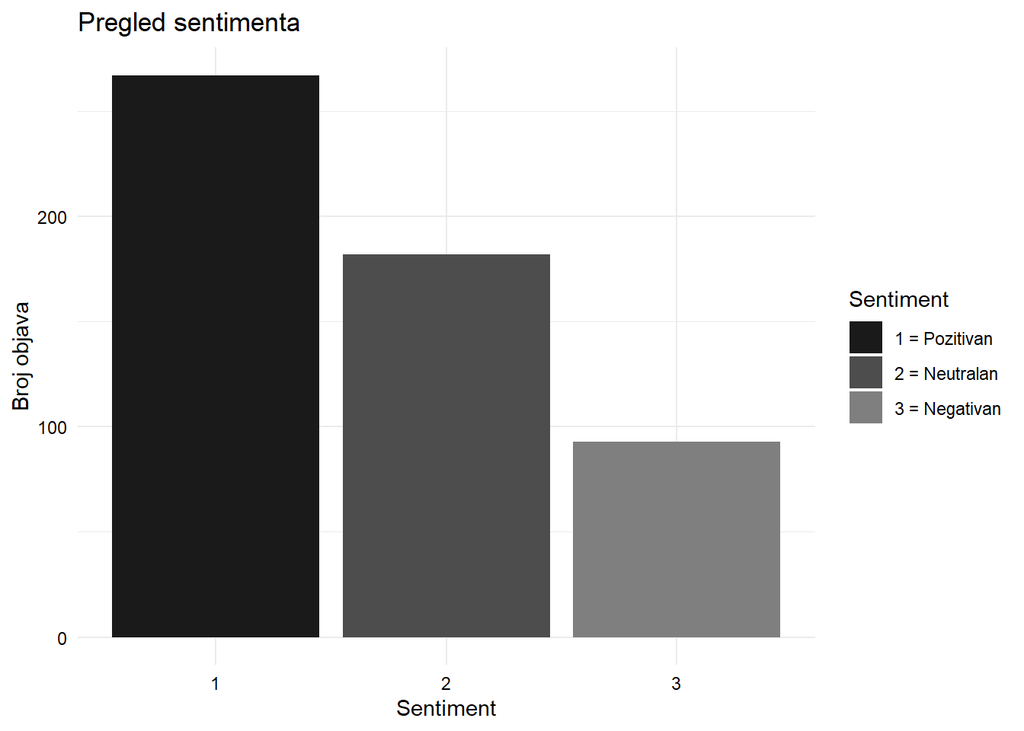

#### prema NRC riječniku (broj pozitivnih - broj negativnih riječi u članku):

#### prema CroSentilex riječniku (broj pozitivnih - broj negativnih riječi u članku):

#### Oblak riječi sa sentimentom CroSentilex (za Financijsku industriju, i.e. 1); ispod toga je doprinos riječi sentimentu za industriju

#### Oblak riječi sa sentimentom NRC (za Financijsku industriju, i.e. 1); ispod toga je doprinos riječi sentimentu za industriju

[figure not shown]

[figure not shown]

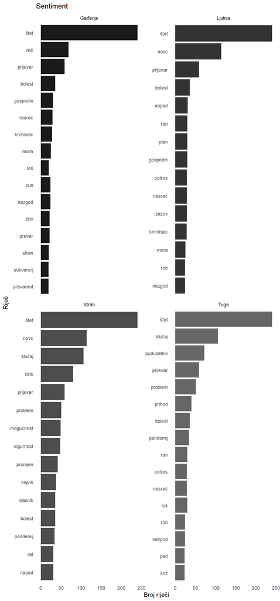

#### Oblak riječi sa sentimentom Crosentilex (za Zdravlje, i.e. 6)

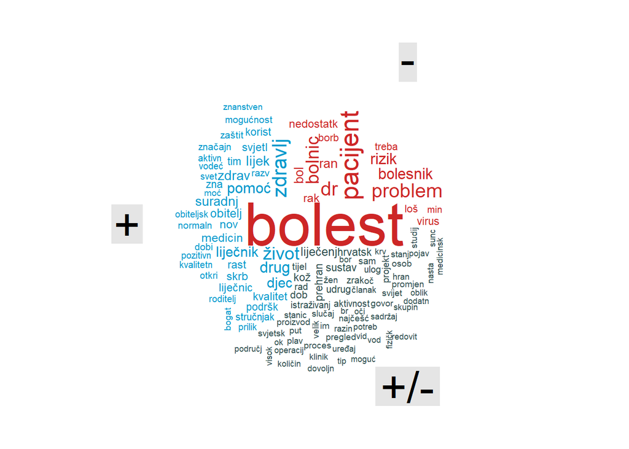

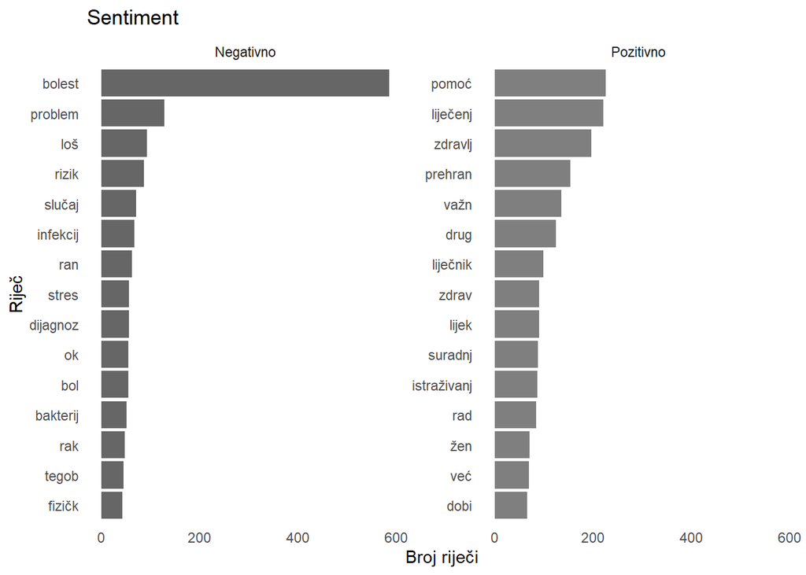

#### Oblak riječi sa sentimentom NRC (za Zdravlje, i.e. 6)

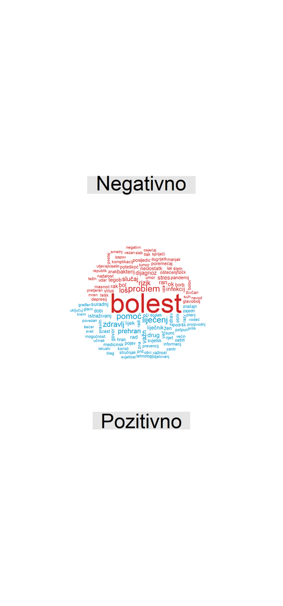